# 02- Report

Minnie Jacobs, Kateryna Chorna, Jemma Hodgkins, Isobelle Clemmens, Gracie Belmonte

2025-10-25

# 1 Predicting Pm10 concentration levels for 2021, using data from different cities in Europe

# 2 Introduction

Throughout this project, we analyse air pollution data from the World Health Organisation, focusing on PM10 concentrations as these pollutant levels are a clear indicator of air quality.

The aim of our project is to analyse various models that can be used to predict PM10 concentration levels for cities in Europe, as this area provided the most complete data, making our results more interpretable. Each model is trained on 90% of our data (using set.seed to ensure we train on the same data), then evaluated on a final validation set. Since our dataset contains a large amount of missing data, this prediction is particularly useful for estimating PM10 levels in cities with incomplete observations, allowing us to capture pollution trends across a wide range of European areas. Each team member applied a different modelling strategy to optimize performance using the same performance metric, we will discuss the suitability of different performance measures such as RMSE for continuous predictions. Although this modelling approach could be extended to other pollutants or regions, we acknowledge that training only on European data limits generalisability to other continents due to differing emission sources and environmental conditions.

## 2.1 Predictive modelling

Before we delve into the different models we used, we still have an issue with the missingness of our data. Although we have identified that European cities are more easily analysed since they have a sufficient amount of their data, some predictive models won’t work with any missing data at all. Hence, we have decided to split our challenge into 2 main categories:

*Predictive modelling with missingness* - here we simply carry out our predictive modelling by using techniques that will still function despite an NA count.

```r
library(dplyr)
europe_data= who_data %>%
  filter(who_region=="4_Eur")%>%
  select(-iso3, -pm10_tempcov, -pm25_tempcov,-who_region,-no2_tempcov, -type_of_stations)%>%
  mutate(log_population = log(population)) # EDA showed a transform was a better predictor of results
```

*Predictive modelling by removing NAs* - We remove the missing data all together, evidently this creates an over smoothing issue, but for the purpose of this task we will still be able to illustrate our results clearly.

```r
clean_data_europe= europe_data %>% select(-pm25_concentration) %>%
na.omit()
```

Note: we can see how many rows were removed, there is a key difference between how many NA values were removed and how many rows were removed, as some rows may contain multiple missing values.

```r
library(dplyr)
europe_rows=nrow(europe_data)
rows_removed=europe_rows-nrow(clean_data_europe)
prop= rows_removed/ europe_rows
prop
```

```
## [1] 0.7160181
```

Hence we have removed 71.6% of our data, so we acknowledge that our models might not be as accurate.

## 2.2 Limiting covariates

Following from previous EDA we have carried out, we decided to include the following covariates in our model as they demonstrated significance in the prediction of pm10 concentration levels:

- **year** (temporal, numeric, discrete)- this variable is essential in capturing trends in pm10 pollutant levels over time.
- **no2_concentration** (environmental)- we found this was a key environmental predictor given it is strongly correlated with pm10_concentration, typically demonstrating an association between the pollutant source.
- **latitude/longitude** (spatial)- important indicators of location, which help us to infer regional differences in pm10 pollution patterns.
- **population/log-population** (demographic, numeric, continuous)- We include this as an indicator of city size. *Due to its large range and skew, we found using a log transform of this improved our results, so this is also included in our model.*

Coverage variables (pm10_tempcov, no2_tempcov) were excluded since they are related to data completeness rather than directly contributing to prediction. Note: We have filtered by european city so can exclude continents, we include - **country_name** - (categorical), we have filtered by European countries as these had the highest amount of data, making our results more interpretable. While we don’t use it directly in our model, we will use it in visualisations of our results.

## 2.3 Performance metric

We read and reviewed a paper discussing various performance metrics in regression models, Plevris et al. (2022), the paper outlined RMSE Root mean squared error) and MAE (Mean absolute error) as key metrics to evaluate accuracy between models.

MAE provides an effective measure of average prediction error, however it is less sensitive to outliers due to the fact all errors are weighted equally. This makes it more robust than RMSE, but less realistic in a real world scenario where outliers are likely to be significant to our predictions.

RMSE is less robust than MAE, but penalises larger deviations, making it a better metric for capturing real world generalisability, for example if we chose to extend our models beyond Europe.

Given our EDA that we carried out, there was a wide range in pollutant concentration for cities in Europe, so some data points could be interpreted as outliers. Because of this, we focused on RMSE as larger errors in high pollution cities are more impactful in our health setting, however we report all 3 to get a better overview of our models, before concluding in ‘04-Conclusion’.

## 2.4 Testing and validation

To assess the performance of our models reliably and ensure their robustness, we must first split our data into two subsets: a test set and a training set.

- The **training set** consists of 90% all data from our cleaned Europe data, we will use this to perform our k-fold CV.
- Our **validation set** is 10% of the data that we randomly select which we use for out of sample validation later.

We use the validation set to see how well our model performs generally, which we could use to predict pm10 concentration for other citities. We note that our models may perform well within Europe, but may not generalise as well outside of this continent.

```r
set.seed(2)
library(caret)
#for models that include missing data
train_index <- sample(seq_len(nrow(europe_data)), size = 0.9 * nrow(europe_data)) #creating a 90-10 split
train_data <- europe_data[train_index, ]
test_data  <- europe_data[-train_index, ]

#for models that don't include missing data
train_index_clean <- createDataPartition(clean_data_europe$pm10_concentration, p = 0.9, list = FALSE) #we create a 90-10 split
train_data_clean <- clean_data_europe[train_index_clean, ]
test_data_clean <- clean_data_europe[-train_index_clean, ]

#now using cross validation:
train_cv= trainControl(method = "cv",number=10)
```

# 3 Modelling with missingness

## 3.1 Model: Random forest

The use of decision trees is both simple and intuitive. They provide a straight forward, visual way to represent how different variables influence a certain outcome by splitting data into small groups based on predictor values. However, single decision trees can be unstable and sensitive to training data. This problem is referred to as over-fitting, where a model performs well on known data but poorly on unseen data. And so minor changes in the dataset can lead to major changes in the predicted outcomes. Hence this makes them inefficient when generalising new, unseen data .

Random Forest trees presents a way of overcoming these issues. The idea is that they combine the predictions of many single decision trees into one robust and accurate model. Instead of relying on a single tree, a Random Forest builds multiple trees using different samples of the data and random subsets of features at each split. The results from all trees are then averaged (for regression) or voted on (for classification) to generate the final prediction.

### 3.1.1 Random Forest Model

```r
#USE CROSS VALIDATION
# Define formula
rf_formula <- pm10_concentration ~ pm25_concentration + no2_concentration +
               population + latitude + longitude
```

### 3.1.2 Train the Random Forest Model

This section implemented the Random Forest algorithm, adapted from BOBBITT (2013)

- The algorithm automatically handled missing values using the `na.roughfix` function that was found from joran (n.d.)
- The default of 500 decision trees was used.
- When building each tree, the `randomForest` algorithm only considers a random subset of the available predictors at each split.
- This randomness prevents dominant predictors, for example `pm25_concentration` from being used in every tree, and thus skewing results.
- The final prediction is the average of all the trees’ output.

```r
library(randomForest)

set.seed(123)
rf_model <- randomForest(
  formula = rf_formula,
  data = train_data, # this will need the whole 90% train data
  na.action = na.roughfix,  # automatically handles missing predictors
  trControl = train_cv
)
rf_model
```

```
##
## Call:
##  randomForest(formula = rf_formula, data = train_data, trControl = train_cv,      na.action = na.roughfix)
##                Type of random forest: regression
##                      Number of trees: 500
## No. of variables tried at each split: 1
##
##           Mean of squared residuals: 29.59306
##                     % Var explained: 73.75
```

### 3.1.3 Visualising our predictions

- In this section, the fitted Random Forest model is used to **predict PM10 concentrations** .
- This procedure again uses code from BOBBITT (2013).

```r
#making our predictions
# use the fitted Random Forest model to predict PM10 values for 2021
predictions <- predict(rf_model, newdata = test_data)
# add the predicted PM10 values to the test dataset
test_data$predicted_pm10 <- predictions
#head(test_data)
```

- The `predict()` function in R takes the fitted Random Forest model object (`rf_model`) and applies it new data (`test_data`).
- `test_data\$predicted_pm10 \<- predictions` creates a new variable within ‘test_data’ data-frame that stores the model’s predicted PM10 values.

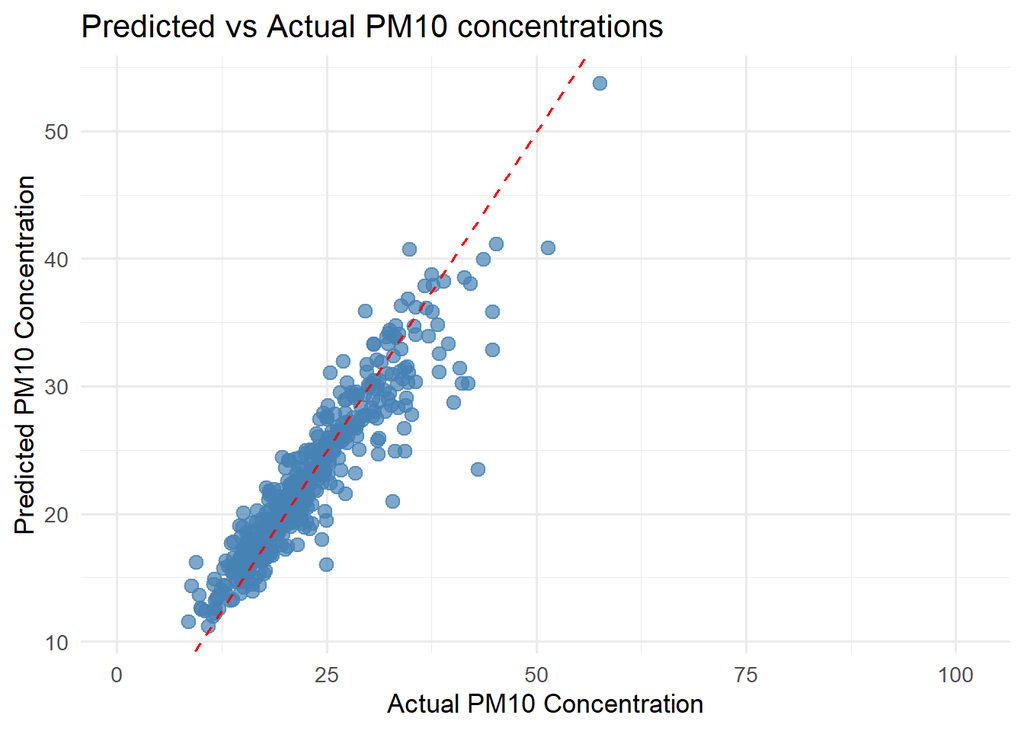

```r
#scatter plot of predicted vs actual PM10
ggplot(test_data, aes( x = pm10_concentration, y = predicted_pm10)) +
  geom_point(colour = "steelblue", size = 3, alpha = 0.7) +
  geom_abline(slope= 1, intercept = 0, colour= "red", linetype = "dashed") +
  labs(
    title = "Predicted vs Actual PM10 concentrations ",
    x = "Actual PM10 Concentration",
    y = "Predicted PM10 Concentration"
  ) +
  theme_minimal(base_size = 13)
```

#### 3.1.3.1 Comments on the scatter plot

- The majority of the points cluster closely around the red line (perfect prediction line), suggesting a good alignment of the predicted and observed values.
- This indicates that the Random Forest model successfully captures the key relationships between PM10 and the predictor variables.
- The tightness of the spread represents a low overall error, however there are a few outliers present for the higher pollution levels.
- These high pollution levels are predicted less accurately, likely because such extreme pollution levels are under-represented in the training data.
- Overall, this is a good plot and shows a strong predictive performance of the Random Forest model.

### 3.1.4 Evaluate Model Preformance with a metric

In order to assess the performance of my chosen model submission, the Random Forest model, our group has chosen to use the **Root Mean Squared Error (RSME)**.

We have found the RSME, R^2 and MAE using code adapted from Lea (n.d.), Kosourova (n.d.) and KingJulian (n.d.) (respectively).

```r
RSME <- sqrt(mean((test_data$pm10_concentration - test_data$predicted_pm10)^2, na.rm = TRUE))

cat("Root Mean Squared Error (RMSE):", round(RSME, 3), "\n")
```

```
## Root Mean Squared Error (RMSE): 2.815
```

```r
#calculate R^2

model_r2 <- lm(test_data$predicted_pm10 ~ test_data$pm10_concentration)
R2 <- summary(model_r2)$r.squared
cat("R-squared (R²):", round(R2, 3), "\n")
```

```
## R-squared (R²): 0.862
```

```r
# Calculate MAE
MAE <- mean(abs(test_data$pm10_concentration - test_data$predicted_pm10), na.rm = TRUE)
cat("Mean Absolute Error (MAE):", round(MAE,3),"\n")
```

```
## Mean Absolute Error (MAE): 1.878
```

### 3.1.5 Analyse Feature Importance

A useful strength of the Random Forest model is that they can provide a direct measure of **feature Importance**, in other words, quantifying how much each variable contributed to the models prediction.

This is calculated using how much each variable reduces the model’s prediction error across all trees in the forest. We used code adapted from Wiber (n.d.).

```r
# extract feature importance from the Random Forest Model

importance_df <- importance(rf_model) %>%
  data.frame() %>%
  mutate(Feature = rownames(.))


#Display
colnames(importance_df)
```

```
## [1] "IncNodePurity" "Feature"
```

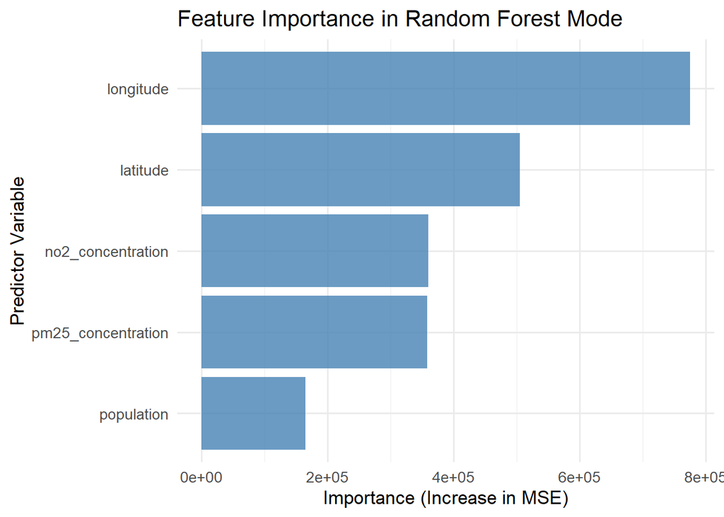

```r
#Plot Feature Importance
library(ggplot2)

ggplot(importance_df,aes(x = reorder(Feature, IncNodePurity), y = IncNodePurity)) +
  geom_bar(stat = "identity", fill = "steelblue", alpha = 0.8) +
  coord_flip()+
  labs(
    title = "Feature Importance in Random Forest Mode",
    x = "Predictor Variable",
    y = "Importance (Increase in MSE)"
  ) +
  theme_minimal(base_size = 13)
```

#### 3.1.5.1 Discussion of the graph

- The x-axis represents the importance score `IncNodePurity`, which is the amount each variable improves the model’s ability to make accurate splits across all trees in the Random Forest.
- The y-axis lists the predictors: `longitude`, `latitude`, `pm25_concentration`, `no2_concentration` and `population`.

#### 3.1.5.2 Interpretation

- `Longitude` was the most influential variable, the model relies heavily on a location’s east-west position to predict PM10. This suggests the presence of clear geographic patterns in air pollution across Europe, possibly linked to regional industrial activity or atmospheric conditions.
- `population` has the lowest importance score, implying that population density plays a minor role once environmental and geographical variables are considered.

### 3.1.6 Conclusion

In conclusion, by combining multiple decision trees to capture non-linear patterns between air pollution, geography and population, the Random Forest model provided an effective approach to predicting PM10 levels across Europe.

With an RSME of **2.8$\mu g/m^3$**, the model achieved a strong level of predictive accuracy, confirming that this algorithm gives a good generalisation to unseen air quality data. Overall, we can confidently say that the Random Forest proved to be a robust and realistic modelling approach for our air quality regression problem.

## 3.2 Model: XGboost

This model can be found in ‘03 Report_Python’, we discuss our findings in the conclusion.

# 4 Modelling without missingness

## 4.1 Model: Linear regression (with regularisation)

In this section, we use linear regression to model pm10 concentration across European cities using several explanatory factors such as no2 concentration, population, and geographic features such as longitude and latitude. We then extend our regression exploration to Ridge, LASSO, and Elastic Net to address potential multicollinearity and improve predictive performance. We evaluate our model’s performance using k-fold cross-validation to train our model, which uses out of sample validation on data from our dataset to assess the generalisation of our model.

From previous EDA that we carried out, we found that using the ‘openair’ package (https://rdocumentation.org/packages/openair/versions/2.19.0) showed a negative linear trend between pm10 concentration and time, suggesting that linear regression is an appropriate modelling approach.

Linear regression cannot work if we have missing values, so for this we use our clean_europe_data.

### 4.1.1 Model equation

Since we have identified our significant covariates, we now consider transforms and non-linear relationships to create additional variables that can capture more information within the model: *no2_concentration: this doesn’t have a strictly linear relationship so we include non-linear terms in our model to capture this.*

*longitude and latitude: These are strongly related so we consider their interaction term as a key variable in our linear model.*

So we can give our model using the following equation:

$$\text{PM}_{10,i} = \beta_0 + \beta_1 \cdot \text{Year}_i+\beta_2 \cdot
\text{Year}_i^2 +\beta_3 \cdot\text{No2}_i+\beta_4
\cdot\text{No2}_i^2+\beta_5 \cdot\text{No2}_i^3+\beta_6 \cdot
\text{population}+\beta_7 \cdot \text{log_population}+\beta_8 \cdot
\text{longitude}+\beta_9 \cdot \text{latitude}+\beta_{10} \cdot
\text{longitude}* \text{latitude}_i+ \varepsilon_i,$$

where $\varepsilon_i \sim N(0,\sigma^2)$.

```r
#using our formula aforementioned:
lm_formula_pm10=pm10_concentration ~ poly(year, 2)+poly(no2_concentration,3) +population+log_population+ longitude+latitude+ latitude*longitude
```

### 4.1.2 Test/train

```r
library(caret) #We use the package 'caret' that we saw in the workshop 2.3.
#now using cv: (we use 10 folds, as we don't have too much data, but it reduces bias)
modelcv=train(lm_formula_pm10, data = train_data_clean, method = "lm" ,trControl=train_cv)

summary(modelcv$finalModel)
```

```
##
## Call:
## lm(formula = .outcome ~ ., data = dat)
##
## Residuals:
##     Min      1Q  Median      3Q     Max
## -28.293  -4.039  -0.720   3.183 108.712
##
## Coefficients:
##                                 Estimate Std. Error t value Pr(>|t|)
## (Intercept)                    4.275e+01  9.736e-01  43.913  < 2e-16 ***
## `poly(year, 2)1`              -1.485e+02  7.689e+00 -19.318  < 2e-16 ***
## `poly(year, 2)2`               6.005e+00  6.714e+00   0.894   0.3711
## `poly(no2_concentration, 3)1`  2.154e+02  7.802e+00  27.609  < 2e-16 ***
## `poly(no2_concentration, 3)2` -1.958e+00  7.062e+00  -0.277   0.7815
## `poly(no2_concentration, 3)3`  5.865e+01  6.713e+00   8.737  < 2e-16 ***
## population                     1.515e-08  1.149e-07   0.132   0.8951
## log_population                 4.120e-01  6.948e-02   5.930 3.17e-09 ***
## longitude                     -3.042e-02  1.736e-02  -1.752   0.0798 .
## latitude                      -6.062e-01  1.327e-02 -45.679  < 2e-16 ***
## `longitude:latitude`           1.019e-02  4.287e-04  23.763  < 2e-16 ***
## ---
## Signif. codes:  0 '***' 0.001 '**' 0.01 '*' 0.05 '.' 0.1 ' ' 1
##
## Residual standard error: 6.604 on 6840 degrees of freedom
## Multiple R-squared:  0.4403, Adjusted R-squared:  0.4395
## F-statistic: 538.1 on 10 and 6840 DF,  p-value: < 2.2e-16
```

### 4.1.3 Model fit

```r
modelcv$results
```

```
##   intercept     RMSE  Rsquared      MAE    RMSESD RsquaredSD     MAESD
## 1      TRUE 6.621294 0.4387229 4.730187 0.4552936 0.04011078 0.1256223
```

We saw from our model that the cross-validated linear regression achieved an RMSE of 6.621294 on the training set. This means that on average, the model’s predictions of PM10 concentrations deviate from the observed values by about $6.621 \mu g/m^3$, this is a relatively high error, suggesting linear regression struggles to capture more complex relationships within the data.

### 4.1.4 Model assumptions

We test our model’s fit on the linear regression assumptions:

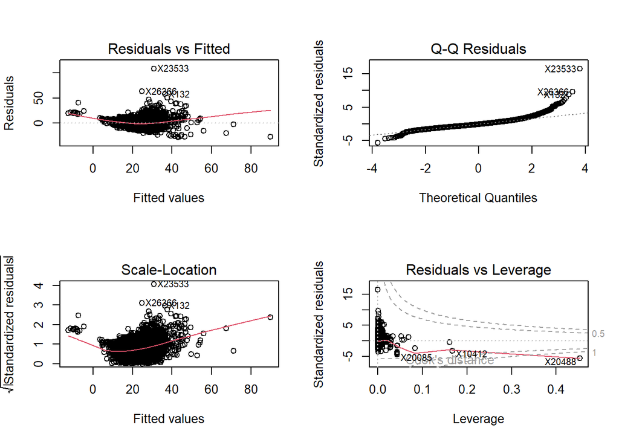

```r
par(mfrow = c(2, 2))
plot(modelcv$finalModel)
```

As we can see from the model fit:

*Residuals vs fitted :* The residuals are fairly randomly scattered, but with a curved, quadratic distribution suggesting our assumption for linearity doesn’t entirely hold.

*Q-Q residuals:* The residuals mostly lie in a diagonal line apart from at the tails, where we see extreme values that are not explained by the model, removing outliers could improve the performance of our model.

*Scale-location:* The residuals are randomly scattered around the line, but with a curvature heavily dropping around 15 on the fitted values, the constant variance assumption doesn’t fully hold.

*Residuals vs leverage:* We see most of our data is clustered around the left hand side of the graph, suggesting we have a left skew. There appear to be a few points of high leverage.

Hence, we haven’t fitted the optimal model since our assumptions have been violated. Because of this, we expect other models to perform better in our ‘artificial competition’.

### 4.1.5 Extending our linear regression by regularising

After carrying out a literature review on how to improve our model, we came across a paper on using Chen et al. (2019), where we build upon the ideas of linear regression by regularising, this means we penalise larger coefficients in order to control the variance and reduce the effects of multicollinearity.

It works by adding the second term in our linear regression:

$$\min_{\boldsymbol{\beta}} \sum_{i=1}^{n} (y_i - \mathbf{x}_i^\top
\boldsymbol{\beta})^2
+ \lambda \left[(1-\alpha)\sum_{j}\beta_j^2 +
\alpha\sum_{j}|\beta_j|\right]$$

Where $\lambda$ controls the shrinkage, and $\alpha$ indicates the method. There are a variety of ways of doing this, we focus on the following methods:

- Ridge: $\alpha=0$, Reduces the size of all of the coefficients, but keeps them in the model. We have correlation between some predictors so this method should smooth out any instabilities this causes.
- Lasso: $\alpha=1$, This method is similar to Ridge, but can shrink some coefficients all the way to zero, automatically removing less important variables.
- Elastic (combines Ridge and Lasso): It keeps Ridge’s stability and LASSO’s ability to select variables, balancing the two through a mixing parameter $\alpha$.

```
##         Model     RMSE        R2      MAE
## 1      Linear 6.621294 0.4387229 4.730187
## 2       Ridge 6.649507 0.4344100 4.719030
## 3       LASSO 6.608980 0.4366445 4.726464
## 4 Elastic Net 6.621825 0.4366230 4.717779
```

After running the code for our Ridge, LASSO and Elastic Net, we obtained the above table of comparisons.

Evidently, the values we can see in our table are all are fairly similar, so evaluating the performance of each model is more nuanced than a clearly defined optimal model.

We see that the LASSO method has the lowest RMSE (Root Mean Squared Error) of 6.608980, meaning it produces the smallest average prediction error on the unseen data, making it potentially more accurate.

Regarding the R^2 value, we can see the Linear model has the highest value, suggesting that when we tested our model on our unseen data, it explained 43.87% of the variation in pm10 concentrations across the European cities.

Meanwhile the method with the smallest MAE (Mean Absolute Error) is the Elastic Net method. Meaning we can deduce that Elastic Net deviates the least from our true PM10 concentrations.

Now using our model we can use our out of sample data to predict pm10 concentration:

```r
# Predict PM10 for all observations in the dataset
test_data_clean$predicted_pm10 <- predict(lasso_model, newdata = test_data_clean)
#now our results:
results=data.frame(
  actual_pm10 = test_data_clean$pm10_concentration,
  predicted_pm10 = test_data_clean$predicted_pm10,
  country = test_data_clean$country_name)
```

We visualise the relationship between actual pm10 values and predicted pm10 values for European cities, we have coloured the cities by their corresponding countries:

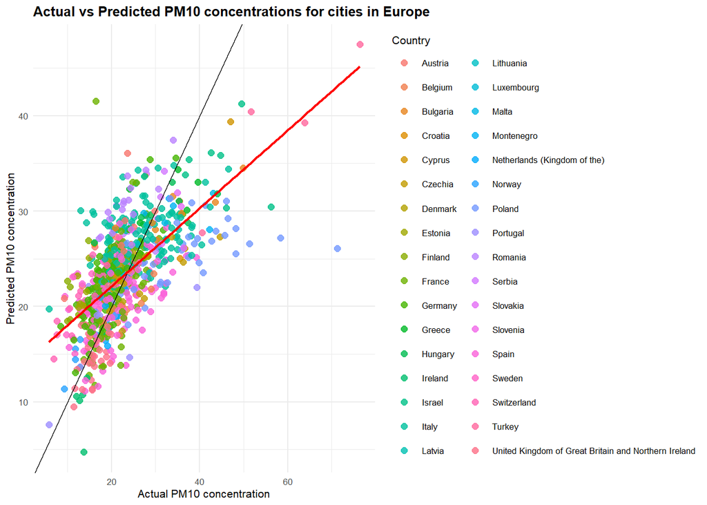

```r
library(ggplot2)
ggplot(results, aes(
  x = actual_pm10,y = predicted_pm10,color = country)) +
  geom_point(alpha = 0.8, size = 2) +
  geom_abline(intercept = 0, slope = 1, color = "black") +geom_smooth(method = "lm", se = FALSE, color = "red")+
  labs(title = "Actual vs Predicted PM10 concentrations for cities in Europe",
    x = "Actual PM10 concentration",y = "Predicted PM10 concentration",
    color = "Country"
  ) +
  theme_minimal(base_size = 8) +
  theme(legend.position = "right",plot.title = element_text(face = "bold"))
```

In our figure we have included the 1:1 reference line (perfect prediction line) in black, and our regression line in red.

We can see from our figure that most of our data is clustered around the lower left of our data set, suggesting many of our pm10 pollution levels are lower in value. There are many points evenly distributed around the 1:1 reference line, suggesting a fairly good model fit, with the exception of a few outliers in cities located in France, Israel, Ireland and Italy. These may be due to political or meteorological conditions that we haven’t considered in our model. We could consider removing these city outlier points, as it would increase the model performance, however this would also introduce a bias to our model. We also note these outlier points are for higher pollution levels, so removing these would lead to a bias towards lower PM10 concentrations.

Overall our model appears to provide a reasonably good prediction for a variety of cities in Europe, however we identify a few outliers which have slightly skewed the prediction accuracy of our model for higher level pm10 concentrations.

### 4.1.6 Conclusions for Linear regression

We also used transforms of variables, such as log population and polynomial terms for both the no2 concentration and year variables. This helped to capture the non-linearity aspects of our model. However we did find that our model assumptions were violated for the linearity assumption, suggesting further transforms or more explanatory variables should be included to improve our model.

Significant predictors we found were year (which is to be expected given the negative correlation of our pm10 concentrations over time), no2 concentrations spatial locations and log population.

To amend this and further our analysis, we would need to consider additional explanatory variables, these could include:

1. Weather conditions - temperature, wind speed, humidity.
2. Industrial emissions.
3. Traffic density.

Including these variables could help to address the assumption violations we found in our model, potentially increasing the explanatory power of the model and providing us with a better understanding of the factors influencing the pm10 concentration levels for cities in Europe.

## 4.2 Model: Robust regression

We have seen in section Linear Regression how to address multicollinearlity and overfitting with the ridge, lasso and elastics net regression. Now we will look at robust regression models, these models perform more reliably when the data contains outliers. This can be particularly useful in environmental data since there can be anomalies in the data due to short term events such as fires or storms or faulty equipment. However, as our data is the average pm10 concentration from the given year in a given city anomalies may be less likely since we already have an average not the individual values from throughout the year.

In our above working we have been using the ordinary least squares residual which aims to minimise the function $\sum_i (y_i - x_i^T \beta )^2$. As we can see from this equation residuals get quadratic penalties and hence very large residual can dominate the fit.

For the next section we found a source Venables and Ripley (2002) that explained robust and resistant regression and the packages required in R.

Robust regression minimises a weighted loss function so large residuals have less influence.

For a given density $f$ we define the loss function as $\rho = - \log f$

So the MLE estimator solves $\min_ \mu \sum_i - \log f (y_i - \mu) = \min _\mu \sum_i \rho (y_i - \mu)$, we set $\psi$ to be the derivative of $\rho$ so $\psi = \rho '$. To find the minimum we set the derivative of the function to zero and hence we get $\sum_i \psi (y_i - \hat{\mu}) =0$. We can also write this in the weighted form with $\sum_i w_i(y_i-\hat{\mu})=0$ where $w_i =\psi (y_i-\hat{\mu})/(y_i-\hat{\mu})$ is the weight of each iteration in the algorithm.

In particular we will look at three robust models which each define $\psi$ differently:

Huber: $\chi (x) = \psi (x)^2 = \min (|x|,c)^2$ where $c=1.5$ is the default.

Tukey : $\psi(t) = t[1-(\frac{t}{R})^2] _+^2$ where the value $R= 4.685$ gives a $95%$ efficiency at the normal.

Hampel: is a piecewise function for example $\psi(x) = \text{sgn} (x) \begin{cases} |x| & \ 0<|x| <a \\ a & a<|x| <b \\ a(c-|x|)/(c-b) & \ b<|x|<c \\ 0 & c<|x| \end{cases}$

The main difference between these models is how quickly they downweigh the outliers, Tukey is the most resistant as it completely rejects very large residuals, Hampel takes a middle ground moderately downweighing and only removing very extreme values and Huber is the least aggressive down weighing residuals but never fully removing them.

We will continue using the same equation for our model as in the Linear Regression section.

```r
lm_formula_pm10=pm10_concentration ~ poly(year, 2)+poly(no2_concentration,3) +population+log_population+ longitude+latitude+ latitude*longitude
```

Applying the robust regression models described above requires the use of the rlm() function from the MASS library, where we can specify the robustness function by choosing $\psi$ as described in Venables and Ripley (2002). However we have previously used the train() function from the caret library in order to conduct cross validation on the model however this doesn’t support the rlm() function needed to conduct robust regression. Consequently we have to perform the cross validation manually.

From James et al. (2021) we define k-fold Cross Validation as $CV_{(k)} = \frac{1}{k} \sum_{i=1}^k \text{MSE}_i$, in K fold cross validation we divide the set of observations into k groups of equal size, the first fold is treated as validation set then the model is fit on the remaining k-1 folds. Mean squared error MSE is computed for each fold and an average of this is computed. In order to find the performance metrics we are using we must compute them from the equations:

$RMSE = \sqrt{\frac{1}{n} \sum_{i=1}^n (y_i-\hat{y}_i)^2)} = \sqrt{MSE}$

$MAE = \frac{1}{n} \sum_{i=1}^n |y_i-\hat{y}_i|$

$R^2 = 1 - \frac{SS_{res}}{SS_{tot}} = 1- \frac{\sum_{i=1}^n (y_i-\hat{y}_i)^2}{\sum_{i=1}^n (y_i-\bar{y})^2}$

where $y_i$ is the actual value, $\hat{y}_i$ is the predicted value from the model used and $\bar{y}$ is the mean of the actual values. And so from this we create a function to perform cross validation using the rlm() function as our model.

```r
data <- train_data_clean  # clean training dataset
lm_formula_pm10 <- pm10_concentration ~ poly(year, 2) + poly(no2_concentration, 3) +
                 population + log_population + longitude + latitude + latitude*longitude

set.seed(42)
k <- 10
folds <- sample(1:k, nrow(data), replace = TRUE)
cv_rlm <- function(formula, data, psi_function, k_folds) {
  rmse <- rep(NA, k_folds)
  r2   <- rep(NA, k_folds)
  mae  <- rep(NA, k_folds)

  for (i in 1:k_folds) {
    train_fold <- data[folds != i, ]
    test_fold  <- data[folds == i, ]

    model <- rlm(formula, data = train_fold, psi = psi_function)

    pred <- predict(model, newdata = test_fold)
    actual <- test_fold$pm10_concentration

    rmse[i] <- sqrt(mean((actual - pred)^2))
    mae[i]  <- mean(abs(actual - pred))

    # R²: 1 - SS_res / SS_tot
    ss_res <- sum((actual - pred)^2)
    ss_tot <- sum((actual - mean(actual))^2)
    r2[i]  <- 1 - ss_res/ss_tot}

  data.frame(
    Model = deparse(substitute(psi_function)),
    RMSE = mean(rmse),
    MAE  = mean(mae),
    R2   = mean(r2))}
```

### 4.2.1 Resistant Regression

In addition to robust regression, resistant regression also performs more reliably when outliers are present in the dataset. However resistant regression doesn’t minimise the ordinary least squares equation, it minimises a different loss function which ignores the extreme points rather than just downweighing them. In particular we will look at:

Least median of squares, LMS: $\min_b \text{median} |y_i - x_ib|^2$ this minimises the median of squared residuals. It can be very inefficient as it has a converging rate of $\frac{1}{\sqrt[3]{n}}$.

Least trimmed squares regression, LTS: $\min_b \sum_{i=1}^q |y_i -x_ib|^2_{(i)}$ where $q=(n+p+1)/2$, this minimises the sum of the smallest q squared residuals.

S-estimation: finds the solution to $\sum_{i=1}^n \chi (\frac{y_i-x_ib}{c_0s}) = (n-p)\beta$ with small scale s, $\chi$ is usually chosen as $\chi (u) = u^6 -3u^4 + 3u^2, |u| \leq 1$ and $c_0= 1.548$ and $\beta = 0.5$ are chosen for consistency at the normal distribution of errors.

Comparing these three models, LMS is the most resistance, LTS is moderately resistant and retains a good efficiency and S-estimator is the least aggressive but is more efficient than LTS and LMS.

### 4.2.2 Comparing the models

```r
set.seed(42)
cv_results <- bind_rows(
  cv_rlm(lm_formula_pm10, data, psi.huber, k),
  cv_rlm(lm_formula_pm10, data, psi.bisquare, k),
  cv_rlm(lm_formula_pm10, data, psi.hampel, k),
  cv_lqs(lm_formula_pm10, data, "lms", k),
  cv_lqs(lm_formula_pm10, data, "lts", k),
  cv_lqs(lm_formula_pm10, data, "S", k)
)
cv_results
```

```
##          Model      RMSE      MAE         R2
## 1    psi.huber  6.737082 4.642810  0.4127671
## 2 psi.bisquare  6.856300 4.636126  0.3915790
## 3   psi.hampel  6.839700 4.666327  0.3941493
## 4      lqs_lms 10.623502 5.791380 -0.5114401
## 5      lqs_lts 11.231204 5.868474 -1.0085990
## 6        lqs_S 11.310397 5.975756 -0.8207635
```

So we conclude that the robust models performed much better than the resistant models. In particular, the huber model performed the best and therefore we select the Huber model to predict the PM10 concentrations.

### 4.2.3 Predicting

Using the huber model to predict the pm_10 concentration we get,

```r
# Predict PM10 for all observations in the dataset
huber_model <- rlm(lm_formula_pm10, data = train_data_clean, psi = psi.huber)
test_data_clean$pred_pm10_huber    <- predict(huber_model, newdata = test_data_clean)

#now our results:
results=data.frame(
  actual_pm10 = test_data_clean$pm10_concentration,
  pred_pm10_huber = test_data_clean$pred_pm10_huber,
  country = test_data_clean$country_name)
```

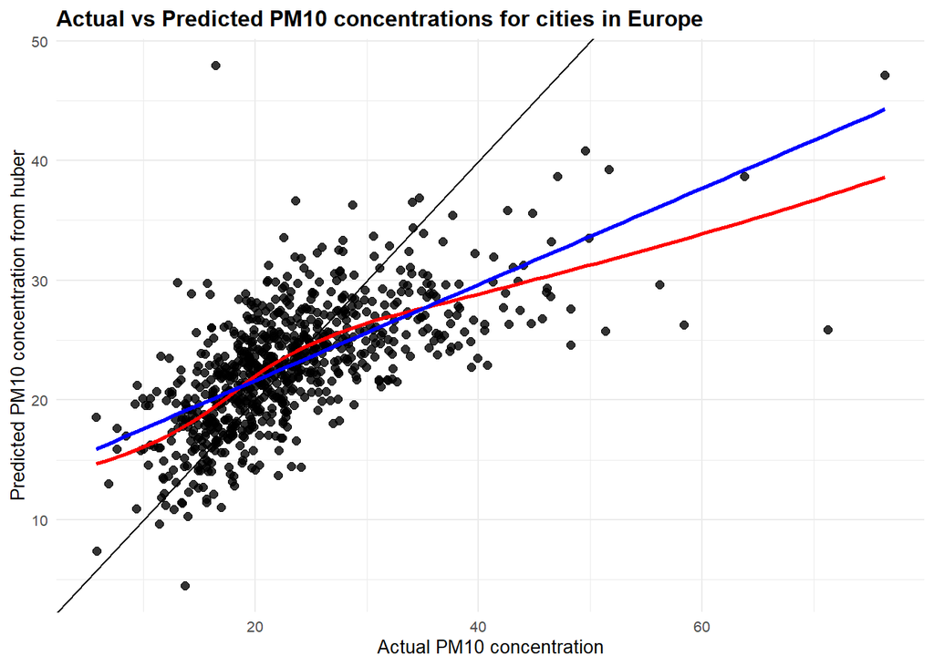

```r
library(ggplot2)
ggplot(results, aes(
  x = actual_pm10,y = pred_pm10_huber)) +
  geom_point(alpha = 0.8, size = 2) +
  geom_abline(intercept = 0, slope = 1, color = "black") +geom_smooth(method = NULL , se = FALSE, color = "red")+geom_smooth(method = 'lm' , se = FALSE, color = "blue")+
  labs(title = "Actual vs Predicted PM10 concentrations for cities in Europe",
    x = "Actual PM10 concentration",y = "Predicted PM10 concentration from huber"
  ) +
  theme_minimal(base_size = 10) +
  theme(legend.position = "right",plot.title = element_text(face = "bold"))
```

Similarly to the graph in the Linear Regression section, we have plotted the actual pm10 values vs the predicted pm10 with two smoothing lines, the blue line indicated the linear regression line and the red line is the automatic smoothing model within ggplot2. At the start we have more clustering of points near to the perfect prediction line indicating these points were predicted better. As the actual pm10 value gets higher the predicted values gets much further from the actual value.

### 4.2.4 Conclusion

We have explored how robust regression assigns lower weights to outliers, reducing their influence, while resistant regression methods largely ignore extreme observations altogether. In our dataset, the resistant regression models performed poorly, producing large errors and low R^2 values, indicating weak predictive ability. The robust regression models, on the other hand, performed significantly better, with the Huber model achieving the lowest RMSE and highest R^2. We therefore conclude that the Huber model provides the best balance between sensitivity to data and robustness to outliers. However, its performance was still limited this could be because the covariates we used in the model don’t fully explain the variability in pm10, for example there might be other variables that are not in the dataset that could help explain this, for example temperature or industrial activity. In addition, the model we specified might not fully capture the non linear relationship between the predictors and pm10 concentration.

## 4.3 Model: Support vector machines

Support Vector Machines are supervised learning models used for both classification and regression problems. They work by finding an optimal boundary, known as a hyperplane, that best separates or predicts data points. The observations that lie closest to this boundary are called support vectors, and they are the most influential in defining the model.

There are two main types of Support Vector Machines:  
- Support Vector Classification (SVC) which used when the target variable is categorical  
- Support Vector Regression (SVR) which is used when the target variable is continuous

Since we aim to predict PM₁₀ pollutant concentrations, which are continuous values, we use the Support Vector Regression (SVR) model. This model finds a smooth function that predicts PM₁₀ levels but SVR cannot handle missing values directly, so rows containing NA’s must be removed or imputed before training the model.

We will try different kernels in SVR to see which works best for predicting PM₁₀ levels.

1. Linear Kernel
2. Polynomial Kernel
3. RBF (Radial Basis Function) Kernel

We will start with simple kernels and increase complexity to find the best model for PM₁₀ predictions.

### 4.3.1 Linear Kernal SVR

In Linear SVR, we assume a linear relationship between the input features $x_i \in \mathbb{R}^p$ and the target variable $y_i \in \mathbb{R}$. The model seeks a hyperplane $f(x) = w^\top x + b$, that predicts $y$ with minimal error by minimizing the norm $|w|^2$ subject to an $\varepsilon$-insensitive loss.

The linear kernel is defined as $K(x_i, x_j) = x_i^\top x_j$. This kernel implies that no nonlinear transformation of the input space is performed, so the SVR estimates a linear function of the inputs.

We use the linear kernel due to its simplicity, serving as a baseline before introducing more complex kernels such as polynomial or RBF. It allows us to directly evaluate how well a linear model can capture the relationship between features and the target variable.

```r
set.seed(2)
# Fit linear SVR on training data
svr_linear_model <- train(
  pm10_concentration ~ year * no2_concentration + population + latitude + longitude,
  data = train_data_clean,
  method = "svmLinear",     # Linear SVM regression
  trControl = train_cv,
  preProcess = c("center", "scale")  # scale features
)
svr_linear_model
```

```
## Support Vector Machines with Linear Kernel
##
## 6851 samples
##    5 predictor
##
## Pre-processing: centered (6), scaled (6)
## Resampling: Cross-Validated (10 fold)
## Summary of sample sizes: 6166, 6165, 6167, 6165, 6166, 6166, ...
## Resampling results:
##
##   RMSE      Rsquared   MAE
##   6.995009  0.3830889  4.721064
##
## Tuning parameter 'C' was held constant at a value of 1
```

The code fits a linear SVR model using the train function from the caret package. It applies 10-fold cross-validation specified earlier for performance evaluation and standardizes the input features by centering and scaling. This is done so each has a mean of 0 and a standard deviation of 1, ensuring that all inputs contribute equally to the model.

Here the metrics are extracted and printed so we can then compare it against models with different kernels.

```r
rmse_linear <- svr_linear_model$results$RMSE
r2_linear   <- svr_linear_model$results$Rsquared
mae_linear  <- svr_linear_model$results$MAE

# Print all metrics
cat("RMSE (Linear SVR):", rmse_linear, "\n")
```

```
## RMSE (Linear SVR): 6.995009
```

```r
cat("R² (Linear SVR):", r2_linear, "\n")
```

```
## R² (Linear SVR): 0.3830889
```

```r
cat("MAE (Linear SVR):", mae_linear, "\n")
```

```
## MAE (Linear SVR): 4.721064
```

These results show that the linear model explains a moderate amount of the variance in the target variable but still leaves a fair amount of error, suggesting that a linear function might not fully capture the structure in the data. We’ll use this to compare to polynomial and RBF kernels to see if they can model the nonlinear relationships more effectively.

### 4.3.2 Polynomial Kernel SVR

In Polynomial Kernel SVR, the model captures nonlinear relationships between the covariates $x_i \in \mathbb{R}^p$ and the target $y_i \in \mathbb{R}$. The polynomial kernel is defined as $K(x_i, x_j) = (\gamma \, x_i^\top x_j + r)^d,$ where $d$ is the polynomial degree, $\gamma$ is a scaling factor, and $r$ is a constant term. This kernel maps the inputs into a higher-dimensional space, allowing the SVR to fit a nonlinear function while solving a linear problem in the transformed space.  
We use the polynomial kernel to evaluate whether modeling nonlinear interactions improves predictive performance compared to the linear kernel.

We use hyperparameter tuning, which is the process of selecting the best values for model parameters that are not learned directly from the training data but control the model’s behaviour and complexity. This is done to ensure the model generalises well to new data, avoiding underfitting or overfitting.

We fit a polynomial SVR model using 3-fold cross-validation for hyperparameter tuning. The training data is split into multiple folds, and the model is trained on all but one fold while the remaining fold is used for validation. This process is repeated for each fold, and the performance metrics are averaged to provide a more reliable estimate of the model’s generalisation ability. The model searches over a grid of hyperparameters: the degree of the polynomial controls the flexibility of the kernel, the scale parameter adjusts the scaling of the inner product in the kernel, and C is the cost parameter that balances model complexity against tolerance for prediction errors. Here, r is not included, which is acceptable because the input features are standardised.

```r
# After tuning, fit the final model using 10-fold CV with the best parameters
svr_poly_model_final <- train(
  pm10_concentration ~ year * no2_concentration + population + latitude + longitude,
  data = train_data_clean,
  method = "svmPoly",       # Polynomial SVM regression
  trControl = train_cv,     # 10 fold CV for final model training
  tuneGrid = svr_poly_model$bestTune,  # using the best hyperparameters found in tuning
  preProcess = c("center", "scale")  # scale and center the data
)
svr_poly_model_final
```

```
## Support Vector Machines with Polynomial Kernel
##
## 6851 samples
##    5 predictor
##
## Pre-processing: centered (6), scaled (6)
## Resampling: Cross-Validated (10 fold)
## Summary of sample sizes: 6166, 6165, 6166, 6167, 6166, 6165, ...
## Resampling results:
##
##   RMSE      Rsquared   MAE
##   6.174303  0.5207545  4.2923
##
## Tuning parameter 'degree' was held constant at a value of 4
## Tuning
##  parameter 'scale' was held constant at a value of 0.01
## Tuning parameter
##  'C' was held constant at a value of 1
```

We get the result printed for the best hyperparamers.

Here the metrics are extracted and printed so we can then compare it against models with different kernels.

```r
rmse_poly <- svr_poly_model_final$results$RMSE
r2_poly   <- svr_poly_model_final$results$Rsquared
mae_poly  <- svr_poly_model_final$results$MAE

# Print all metrics
cat("RMSE (Polynomial SVR):", rmse_poly, "\n")
```

```
## RMSE (Polynomial SVR): 6.174303
```

```r
cat("R² (Polynomial SVR):", r2_poly, "\n")
```

```
## R² (Polynomial SVR): 0.5207545
```

```r
cat("MAE (Polynomial SVR):", mae_poly, "\n")
```

```
## MAE (Polynomial SVR): 4.2923
```

Our model is already better than the linear one for all the metrics used.

### 4.3.3 RBF (Radial Basis Function) Kernel SVR

Similarly, in the RBF Kernel SVR, the kernel is defined as $K(x_i, x_j) = \exp(-\gamma \|x_i - x_j\|^2),$ where $\gamma > 0$ controls the smoothness of the resulting function by determining how rapidly the influence of a training example decreases with distance. Unlike the polynomial kernel, which models global interactions through polynomial terms, the RBF kernel captures localized nonlinear relationships by implicitly mapping the inputs into an infinite-dimensional feature space. We use the RBF kernel to evaluate whether modeling such localized nonlinear effects further improves predictive performance compared to both the linear and polynomial kernels.

We use hyperparameter tuning again for this kernel to identify the best combination of parameters that yield the highest predictive performance on unseen data. We tune parameters such as the regularization parameter $C$, the kernel coefficient $\gamma$, and, for the polynomial kernel, the degree $d$. In the R implementation, the parameter `sigma` corresponds to the inverse of the kernel width in the theoretical RBF kernel, where $\gamma = 1 / (2\sigma^2)$. Thus, tuning `sigma` in the model effectively controls the same behavior as tuning $\gamma$, influencing how tightly the model fits the data. we use cross-validation to prevent overfitting and the optimal parameter set is then used to train the final SVR model.

```r
#Final model with best parameters using 10-fold CV
svr_rbf_model_final <- train(
  pm10_concentration ~ year * no2_concentration + population + latitude + longitude,
  data = train_data_clean,      # training data
  method = "svmRadial",         # RBF SVM regression
  trControl = train_cv,  # 10-fold CV for final model training
  tuneGrid = svr_rbf_model$bestTune,         # Use the best hyperparameters from tuning
  preProcess = c("center", "scale")  # scale features
)
svr_rbf_model_final
```

```
## Support Vector Machines with Radial Basis Function Kernel
##
## 6851 samples
##    5 predictor
##
## Pre-processing: centered (6), scaled (6)
## Resampling: Cross-Validated (10 fold)
## Summary of sample sizes: 6167, 6166, 6165, 6167, 6167, 6164, ...
## Resampling results:
##
##   RMSE      Rsquared   MAE
##   5.260311  0.6462274  3.374007
##
## Tuning parameter 'sigma' was held constant at a value of 0.5
## Tuning
##  parameter 'C' was held constant at a value of 10
```

We then train the final RBF SVR model using the optimal hyperparameters obtained from tuning and apply 10-fold cross-validation to get a more reliable model that works better on unseen data, and we center and scale the predictors for numerical stability.

Here the metrics are extracted and printed so we can then compare it against models with different kernels.

```r
rmse_rbf <- svr_rbf_model_final $results$RMSE
r2_rbf   <- svr_rbf_model_final $results$Rsquared
mae_rbf  <- svr_rbf_model_final $results$MAE

# Print all metrics
cat("RMSE (RBF SVR):", rmse_rbf, "\n")
```

```
## RMSE (RBF SVR): 5.260311
```

```r
cat("R² (RBF SVR):", r2_rbf, "\n")
```

```
## R² (RBF SVR): 0.6462274
```

```r
cat("MAE (RBF SVR):", mae_rbf, "\n")
```

```
## MAE (RBF SVR): 3.374007
```

This is better than polynomial kernel. We will discuss the results of all kernels in the next section.

### 4.3.4 Conclusion

#### 4.3.4.1 Evaluating the Kernels

We will now evaluate the performance of each SVR model using metrics such as RMSE, MAE, and $R^2$. This will allow us to compare the predictive accuracy of the linear, polynomial, and RBF kernels, and determine which kernel provides the best fit for our data.

```r
#metrics for each kernel
results <- data.frame(
  Model = c("RBF SVR", "Polynomial SVR", "Linear SVR"),
  RMSE = c(rmse_rbf, rmse_poly, rmse_linear),
  R2 = c(r2_rbf, r2_poly, r2_linear),
  MAE = c(mae_rbf, mae_poly, mae_linear)
)
print(results)
```

```
##            Model     RMSE        R2      MAE
## 1        RBF SVR 5.260311 0.6462274 3.374007
## 2 Polynomial SVR 6.174303 0.5207545 4.292300
## 3     Linear SVR 6.995009 0.3830889 4.721064
```

We find that the RBF kernel outperforms the linear and polynomial kernels across all metrics, which is expected given its able to capture complex, nonlinear relationships in the data.

The linear SVR performed relatively poorly, suggesting that the relationship between the covariates and the target variable is not purely linear. During hyperparameter tuning, the polynomial SVR favoured a higher polynomial degree, indicating that the model required a more complex functional form to fit the data effectively. However, this increased model complexity came with a significant computational cost, as significantly increased the training times. In contrast, the RBF kernel captured the nonlinear structure of the data more efficiently, providing a smoother regression function and better overall performance while remaining computationally feasible.

#### 4.3.4.2 Testing RBF SVR on Out of Sample Data

We will now use the out- of sample data to see how well the RBF SVR performs on unseen data and evaluate its generalisation ability.

```r
# Predict on Test Data (unseen)
predictions_rbf_test <- predict(svr_rbf_model_final, newdata = test_data_clean)
```

We plot Actual vs Predicted for each city to visually assess the performance of the RBF SVR model.

```r
# Plot actual vs predicted
p_rbf_test <- ggplot(test_data_clean, aes(
  x = pm10_concentration,
  y = predictions_rbf_test,
  text = paste0("City: ", test_data_clean$city, "<br>Country: ", test_data_clean$country_name)
)) +
  geom_point(color = "darkgreen", alpha = 0.6) +
  geom_abline(slope = 1, intercept = 0, linetype = "dashed", color = "red") +
  labs(
    x = "Actual PM10",
    y = "Predicted PM10",
    title = "Actual vs Predicted for Out of Sample Data"
  ) +
  theme_minimal()
ggplotly(p_rbf_test, tooltip = "text")
```

[interactive chart not shown]

A lot of points lie close to the dashed red line, indicating that the model predicts PM10 concentrations well for many cities. However, some points are quite far from the line, meaning that the model struggles to accurately predict PM10 for certain locations.

```r
# Calculate test set metrics
rmse_rbf_test <- sqrt(mean((test_data_clean$pm10_concentration - predictions_rbf_test)^2))
mae_rbf_test  <- mean(abs(test_data_clean$pm10_concentration - predictions_rbf_test))
r2_rbf_test   <- 1 - sum((test_data_clean$pm10_concentration - predictions_rbf_test)^2) /
                     sum((test_data_clean$pm10_concentration - mean(test_data_clean$pm10_concentration))^2)
cat("Test RMSE (RBF SVR):", rmse_rbf_test, "\n")
```

```
## Test RMSE (RBF SVR): 4.804068
```

```r
cat("Test R² (RBF SVR):", r2_rbf_test, "\n")
```

```
## Test R² (RBF SVR): 0.6771144
```

```r
cat("Test MAE (RBF SVR):", mae_rbf_test, "\n")
```

```
## Test MAE (RBF SVR): 3.285811
```

BOBBITT, ZACH. 2013. “How to Build Random Forests in r.” Statology. 2013. https://www.statology.org/random-forest-in-r/.

Chen, Jie, Kees de Hoogh, John Gulliver, Barbara Hoffmann, Ole Hertel, Matthias Ketzel, Mariska Bauwelinck, et al. 2019. “A Comparison of Linear Regression, Regularization, and Machine Learning Algorithms to Develop Europe-Wide Spatial Models of Fine Particles and Nitrogen Dioxide.” *Environment International* 130: 104934. https://doi.org/https://doi.org/10.1016/j.envint.2019.104934.

James, Gareth, Daniela Witten, Trevor Hastie, and Robert Tibshirani. 2021. *An Introduction to Statistical Learning: With Applications in r*. Second. New York: Springer. https://doi.org/10.1007/978-1-0716-1418-1.

joran. n.d. “How Do i Use Random Forests in r with Missing Values?” Stackoverflow. https://stackoverflow.com/questions/8370455/how-to-use-random-forests-in-r-with-missing-values.

KingJulian. n.d. “Mean Absolute Error in Random Forest Regression.” stackExchange. https://datascience.stackexchange.com/questions/43542/mean-absolute-error-in-random-forest-regression.

Kosourova, Elena. n.d. “R-Squared Explained: How Well Does Your Regression Model Fit?” datacamp. https://www.datacamp.com/tutorial/r-squared.

Lea, Len Greski. n.d. “How Do i Find Out the RMSE of a Random Forest in r.” Stackoverflow. https://stackoverflow.com/questions/60685866/how-do-i-find-out-the-rmse-of-a-random-forest-in-r.

Plevris, Vagelis, German Solorzano, Nikolaos Bakas, and Mohamed Ben Seghier. 2022. “Investigation of Performance Metrics in Regression Analysis and Machine Learning-Based Prediction Models,” June. https://doi.org/10.23967/eccomas.2022.155.

Venables, W. N., and B. D. Ripley. 2002. *Modern Applied Statistics with s*. 4th ed. New York: Springer.

Wiber, Jared. n.d. “How to Get the Most Important Variables in Random Forests in r.” StackExchange. https://stats.stackexchange.com/questions/153663/how-to-get-the-most-important-variables-in-random-forests-in-r.